# 4. Applied regression II

#### ii pp lot / qq plot

**Normal probability plot (p-p plot)** / **Normal quantile plot (q-q plot)** of residuals

- If two variables have the same distribution (plotting dataset against normal distribution), points should **fall on the 45° line on a p-p or q-q plot**
- p-p plot more sensitive to deviation from normality in the middle range; q-q plot more sensitive to outer range

`qqnorm(residual)` `abline(0,1)`

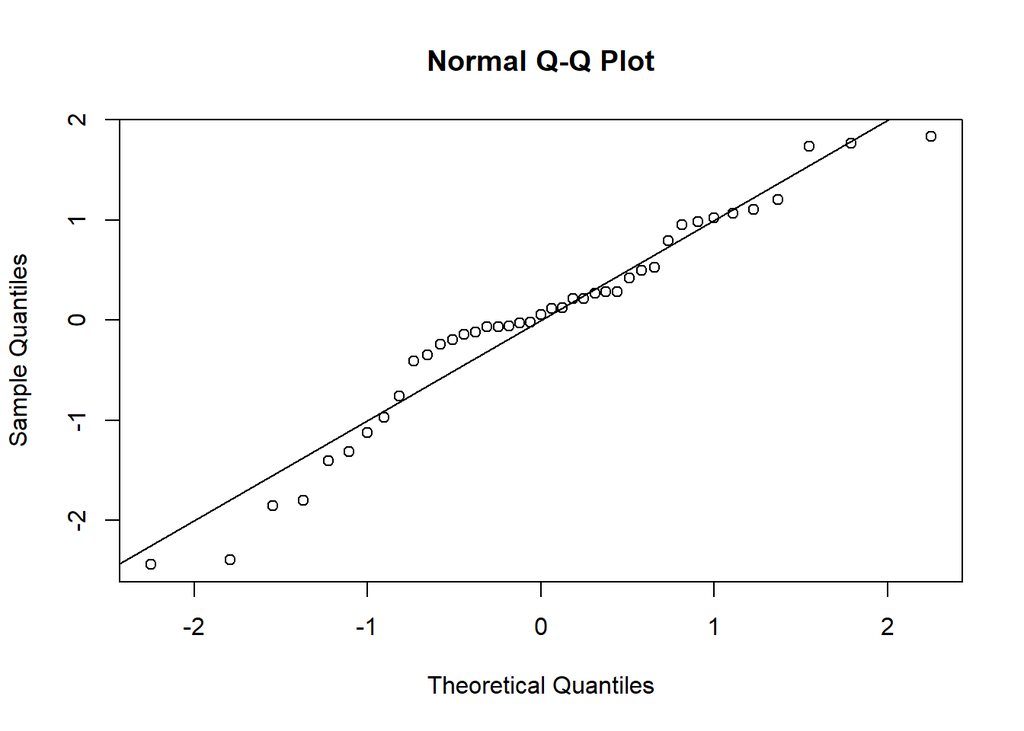

```r
## Q-Q plot
qqnorm(stresid.mvc)
abline(0,1) #no severe deviation from normality
```

```r
## P-P plot (not teached in lecture)
pd.stresid.mvc <- pnorm(stresid.mvc)
plot(ppoints(length(stresid.mvc)), sort(pd.stresid.mvc), main = "PP
Plot", xlab = "Observed Probability", ylab = "Expected Probability")
abline(0,1) #no severe deviation from normality
```

[output not shown]

### D Non-independence of the errors

- Non-independence = serial correlation/autocorrelation
  - Sometimes a by-product of misspecification of the time trend when **time is a predictor** in the model

#### i Residual plot by observations

- Plot **studentized residuals over time**
  - Adjacent errors tend to have the same sign if errors are serially correlated
  - Note: Meaningful only if observations were made sequentially

`plot(residual)`

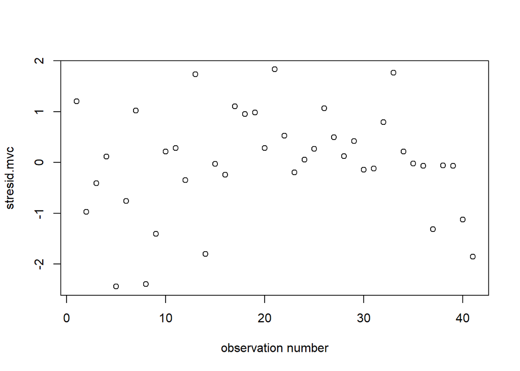

```r
plot(stresid.mvc, xlab='observation number') # No obvious autocorrelation in the residuals
```

#### ii ACF plot

ACF: autocorrelation function

- Correlation between the **same** variable at **different** time point
- X<sub>t</sub> = variable X observed at time t
  - If ACF/PACF exceed threshold/confidence limit in the first few lags –> autocorrelation
  - Correlation for time lag 0 is def 1 coz we are comparing varaibles at same time interval
  - PACF: partial ACF remove effect from other time lags (indirect correlation)

`acf(residual)` `pacf(residual)`

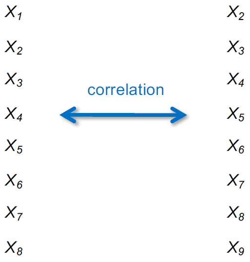

1 time lag

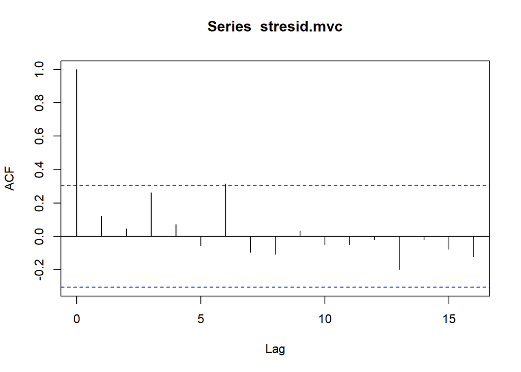

```r
acf(stresid.mvc) #No obvious correlation in the residuals
```

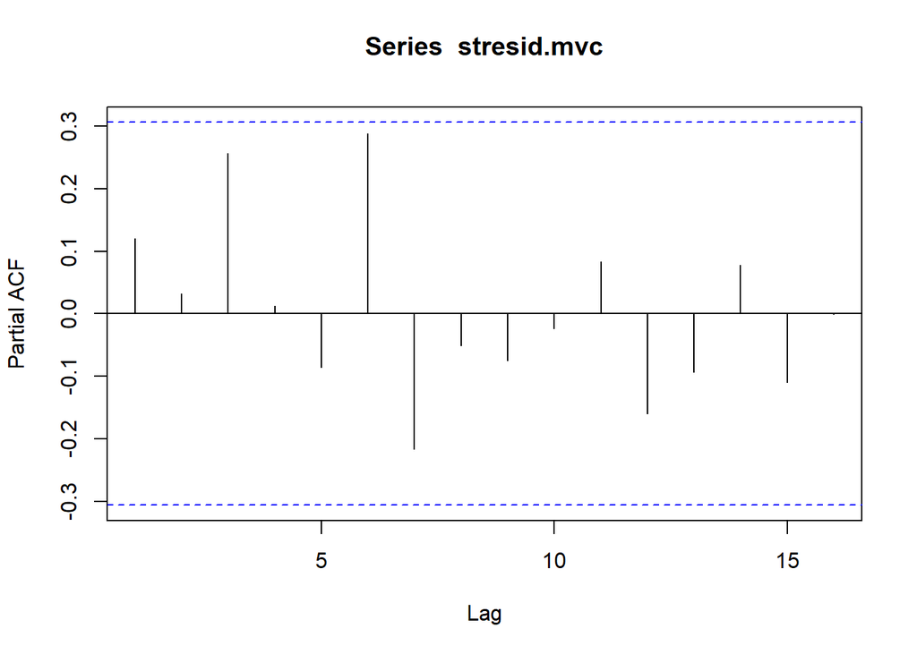

```r
pacf(stresid.mvc) #No obvious correlation in the residuals
```

### Example of plots indicating assumption violations

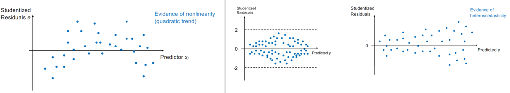

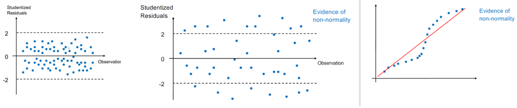

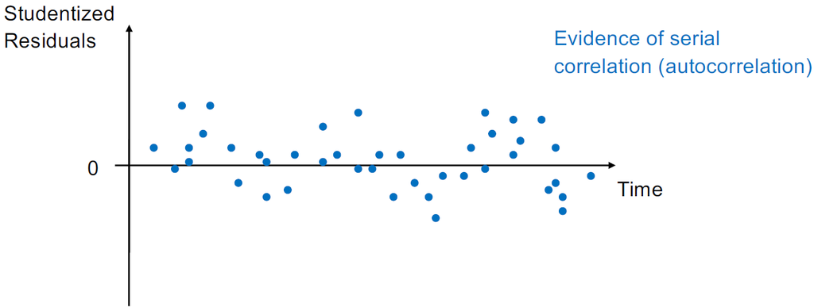

### Consequence of assumption violations for linear regression

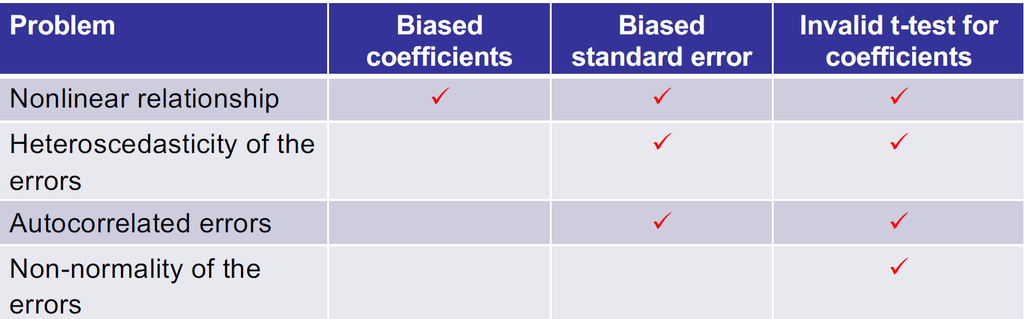

## 3.2 Assumptions of other models – glm

1. Linearity  
   Linear relationship between predictors and dependent variable through a smooth invertible link function
2. Errors can follow a distribution from the exponential family (e.g. Normal, Bernoulli, Poisson)
3. Independence  
   No correlation / autocorrelation between the errors

### Model diagnostics for glm

- Crude residuals are not used coz variance depends on mean
- **Deviance residuals** can be used `glm.model$res`
  - A measure of deviation from the likelihood of a saturated model (fit in the model to data with no. of parameters = no. of data points)
- Studentized deviance residuals can be obtained by `rstudent(glm.model)` – follow a standard normal distribution if the model is correctly specified